# How fast can Victoria’s emergency departments see you? A five-year story of waiting times

Assignment 4 ETC5512

Chenghuiyu Fan - 36427462

Due Date: 2026-6-12

## Data Details

#### Question 1

Victorian public hospitals treat millions of emergency patients each year, yet waiting times vary widely across triage categories and hospital types. This analysis investigates how emergency department (ED) performance in Victoria changed between 2020–21 and 2024–25, and whether triage urgency category (1–5), hospital peer group, and geographic remoteness explain the variation in waiting time compliance rates across the state.

Specifically, the analysis addresses four sub-questions: 1. How did Victoria’s ED compliance rate and median waiting time change over five years (including the COVID disruption and recovery period)? 2. How does Victoria’s performance compare with the national average over the same period? 3. Which triage categories and hospital peer groups show the greatest shortfall in on-time performance? 4. Does geographic remoteness explain variation in on-time compliance across the state, and how does this pattern appear geographically?

#### Question 2

Three data files are used in this analysis.

**Data file 1 — AIHW Emergency Department Care 2024–25 data tables** (XLSX). Released 10 December 2025 by the Australian Institute of Health and Welfare. The file contains over 50 worksheets covering all Australian public hospital EDs from 2020–21 to 2024–25. Key variables include state/territory, hospital peer group, triage category, number of presentations, proportion of patients seen on time (%), and median waiting time (minutes). All figures are pre-aggregated at the state and peer group level; no patient-level records are included.

**Data file 2 — Geoscience Australia National HealthDirect Health Facilities** (CSV). Updated March 2025. Lists the spatial location (latitude and longitude) of all Australian public health facilities. The Victoria subset contains 50 emergency department services. Used to plot the geographic distribution of EDs on the choropleth map.

**Data file 3 — ABS Remoteness Area 2021 Shapefile** (ZIP). Part of the Australian Statistical Geography Standard (ASGS) Edition 3, released July 2021. Contains polygon boundaries dividing Australia into five remoteness classes: Major Cities, Inner Regional, Outer Regional, Remote, and Very Remote. The Victoria polygons are joined with AIHW Table S5.2 performance data to produce the choropleth map.

#### Question 3

The three data files must be downloaded manually and saved into the data/ folder before running this document.

Data file 1: **AIHW Emergency Department Care 2024–25 data tables (XLSX)**.

The dataset covers all Australian public hospital EDs. Key variables include state/territory, hospital peer group, triage category, number of ED presentations, proportion of patients seen on time (%), and median waiting time (minutes). The time series runs from 2020–21 to 2024–25, which covers the COVID disruption period and subsequent recovery. The data is publicly available under an open government licence. All figures are pre-aggregated at the state and hospital peer group level, so there are no direct privacy concerns.

Download steps — Data file 1:

Go to https://www.aihw.gov.au/hospitals/latest-updates-and-downloads/data

Under “Filter by sub topic”, tick the “Emergency department care” checkbox.

The page will filter to show only emergency department files.

Find the entry titled “Emergency department care 2024–25 data tables” (XLSX, 264 kB, dated 10 Dec 2025).

Click the blue DOWNLOAD button on the right.

Save the file as Emergency-department-care-2024-25.xlsx inside the data/ folder of the project.

Data file 2: **Geoscience Australia National HealthDirect Health Facilities (CSV)**.

The dataset lists the spatial location of all Australian public health facilities. Key variables include facility name, suburb, state, service type, latitude, and longitude. The Victoria subset contains 50 emergency department services. These coordinates are used to plot ED locations on the choropleth map produced from Data file 3.

Download steps — Data file 2:

Go to https://ecat.ga.gov.au/geonetwork/srv/eng/catalog.search#/metadata/149331

Scroll down to the Link section near the bottom of the page.

Find the row labelled “Download Spreadsheet (csv) [3.3 MB]” and click it.

Save the downloaded file as 149331_01_1.csv inside the data/ folder of the project.

Data file 3: **ABS Remoteness Area 2021 – Shapefile (ZIP), part of the Australian Statistical Geography Standard (ASGS) Edition 3**.

The file contains polygon boundaries that divide Australia into five remoteness classes: Major Cities, Inner Regional, Outer Regional, Remote, and Very Remote. The Victoria polygons will be joined with AIHW Table S5.2 performance data to produce a choropleth map showing how ED waiting time compliance varies by remoteness zone.

Download steps — Data file 3:

Go to https://www.abs.gov.au/statistics/standards/australian-statistical-geography-standard-asgs-edition-3/jul2021-jun2026/access-and-downloads/digital-boundary-files

Click “Statistics” in the top navigation bar, then “Classifications, standards and methods”, then “Standards”, then “Australian Statistical Geography Standard (ASGS) Edition 3”.

Click “Remoteness Structure” in the left sidebar, then click “Access and downloads”, then click “Digital boundary files”.

Scroll down to the “Remoteness Structure” section on the right side of the page.

Find the row “Remoteness Area - 2021 - Shapefile” and click “Download ZIP”.

Extract the ZIP file and move all extracted files into the data/ folder of the project.

```r
library(tidyverse)
library(readxl)
library(here)
library(sf)
```

Here I read four sheets from the AIHW Emergency Department Care 2024–25 Excel file. The argument skip = 1 skips the merged header row above the data.

```r
t5_1_raw <- read_excel(
  here("data", "Emergency-department-care-2024-25.xlsx"),
  sheet = "Table 5.1",
  skip  = 1
)

t5_3_raw <- read_excel(
  here::here("data", "Emergency-department-care-2024-25.xlsx"),
  sheet = "Table 5.3",
  skip  = 1
)

t6_3_raw <- read_excel(
  here::here("data", "Emergency-department-care-2024-25.xlsx"),
  sheet = "Table 6.3",
  skip  = 1
)

ts5_2_raw <- read_excel(
  here::here("data", "Emergency-department-care-2024-25.xlsx"),
  sheet = "Table S5.2",
  skip  = 1
)
```

Here I read the Geoscience Australia health facilities CSV and the ABS Remoteness Area 2021 shapefile. These are used together to produce the choropleth map in the blog post.

```r
hospital_location <- read_csv(here::here("data", "149331_01_1.csv"))

boundary_data <- st_read(here("data", "RA_2021_AUST_GDA94", "RA_2021_AUST_GDA94.shp"))
```

```
## replacing null geometries with empty geometries
## Simple feature collection with 54 features and 8 fields (with 19 geometries empty)
## Geometry type: GEOMETRY
## Dimension:     XY
## Bounding box:  xmin: 96.81694 ymin: -43.74051 xmax: 167.998 ymax: -9.142176
## Geodetic CRS:  GDA94
```

The following code cleans and reshapes the four AIHW data sheets into tidy format ready for plotting. Here I clean Table 5.1 to produce a tidy time-series of Victoria’s ED performance across five years.

```r
t5_1_clean <- t5_1_raw |>
  rename(state = 1, measure = 2) |>
  filter(state == "Vic") |>
  pivot_longer(
    cols = starts_with("20"),
    names_to = "year",
    values_to = "value"
  )
```

Here I clean Table 6.3, retaining both Victoria and the national total for comparison.

```r
t6_3_clean <- t6_3_raw |>
  rename(admission_status = 1, state = 2) |>
  filter(state %in% c("Vic", "Total")) |>
  pivot_longer(
    cols = starts_with("20"),
    names_to = "year",
    values_to = "value"
  )
```

Here I clean Table 5.3, keeping only the Victoria column and replacing suppressed values with NA.

```r
t5_3_clean <- t5_3_raw |>
  rename(peer_group = 1, triage = 2) |>
  filter(!is.na(triage)) |>
  select(peer_group, triage, Vic) |>
  mutate(
    Vic = if_else(Vic %in% c("n.p.", ". .") , NA, Vic),
    Vic = as.numeric(Vic)
  )
```

Here I clean Table S5.2 in the same way, retaining remoteness area and triage category for Victoria.

```r
ts5_2_clean <- ts5_2_raw |>
  rename(remoteness = 1, triage = 2) |>
  filter(!is.na(triage)) |>
  select(remoteness, triage, Vic) |>
  mutate(
    Vic = if_else(Vic %in% c("n.p.", ". ."), NA_character_, Vic),
    Vic = as.numeric(Vic)
  )
```

Here I filter the health facilities CSV to Victoria’s 50 emergency department services, and prepare the ABS shapefile and ED point locations for mapping.

```r
vic_eds <- hospital_location |>
  filter(STATE == "VIC",
         NHSD_SERVICE_TYPE == "Emergency department service") |>
  select(ORGANISATION_NAME, SUBURB, LONGITUDE, LATITUDE)
```

```r
remote_vic <- boundary_data |>
  filter(STE_NAME21 == "Victoria") |>
  filter(!RA_NAME21 %in% c(
    "Migratory - Offshore - Shipping (Vic.)",
    "No usual address (Vic.)"
  ))

vic_eds_sf <- vic_eds |>
  st_as_sf(coords = c("LONGITUDE", "LATITUDE"), crs = 4326) |>
  st_transform(crs = st_crs(remote_vic))
```

All three files are stored locally in the data/ folder following the download steps above.

#### References

**Data sources**

Australian Institute of Health and Welfare (AIHW). (2025). Emergency department care 2024–25 data tables [Data set]. https://www.aihw.gov.au/hospitals/latest-updates-and-downloads/data

Geoscience Australia. (2025). National HealthDirect health facilities [Data set]. https://ecat.ga.gov.au/geonetwork/srv/eng/catalog.search#/metadata/149331

Australian Bureau of Statistics (ABS). (2021). Remoteness area 2021 – Shapefile [Data set]. Australian Statistical Geography Standard (ASGS) Edition 3. https://www.abs.gov.au/statistics/standards/australian-statistical-geography-standard-asgs-edition-3/jul2021-jun2026/access-and-downloads/digital-boundary-files

**R Packages**

Wickham H, Averick M, Bryan J, Chang W, McGowan LD, François R, Grolemund G, Hayes A, Henry L, Hester J, Kuhn M, Pedersen TL, Miller E, Bache SM, Müller K, Ooms J, Robinson D, Seidel DP, Spinu V, Takahashi K, Vaughan D, Wilke C, Woo K, Yutani H (2019). “Welcome to the tidyverse.” *Journal of Open Source Software*, *4*(43), 1686. doi:10.21105/joss.01686 https://doi.org/10.21105/joss.01686.

Wickham H, Bryan J (2025). *readxl: Read Excel Files*. doi:10.32614/CRAN.package.readxl https://doi.org/10.32614/CRAN.package.readxl, R package version 1.4.5, https://CRAN.R-project.org/package=readxl.

Müller K (2025). *here: A Simpler Way to Find Your Files*. doi:10.32614/CRAN.package.here https://doi.org/10.32614/CRAN.package.here, R package version 1.0.2, https://CRAN.R-project.org/package=here.

Pebesma, E., & Bivand, R. (2023). Spatial Data Science: With Applications in R. Chapman and Hall/CRC. https://doi.org/10.1201/9780429459016

Pebesma, E., 2018. Simple Features for R: Standardized Support for Spatial Vector Data. The R Journal 10 (1), 439-446, https://doi.org/10.32614/RJ-2018-009

## Blog post

### What is this analysis about?

Victorian public hospitals treat millions of emergency patients every year. Waiting times vary widely across the state. Australia measures emergency department (ED) performance by tracking the proportion of patients seen on time for each triage category. Category 1 patients are the most critical and should be seen immediately. Category 5 patients are the least urgent and should be seen within two hours.

### Why analyse Victoria’s ED performance?

I live in Melbourne and use public hospitals. I want to know whether waiting times in Victoria have recovered since the COVID-19 pandemic. I also want to understand whether hospital type and geographic location explain why some patients wait longer than others.

### How has Victoria’s ED performance changed over time?

The first question is how Victoria’s ED performance has changed over the five-year period. The two charts below show the proportion of patients seen on time and the median waiting time from 2020-21 to 2024-25.

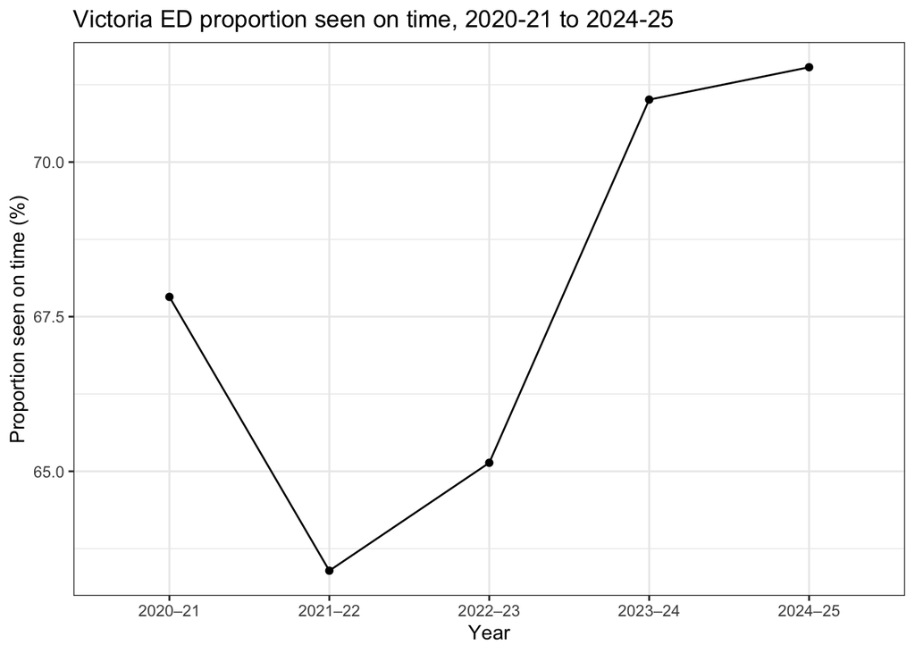

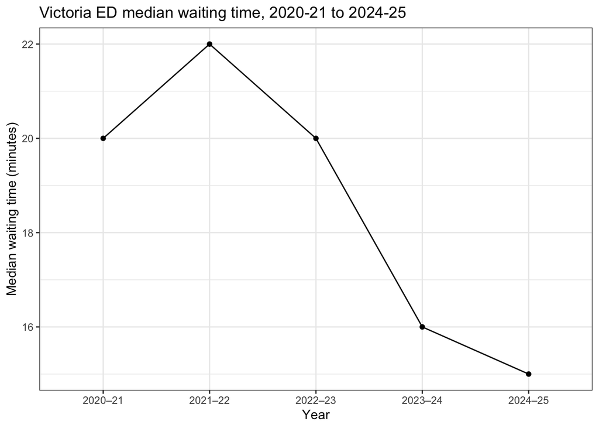

The data show that Victoria’s proportion of patients seen on time dropped to its lowest point in 2021-22 and has since recovered steadily. Median waiting time followed the opposite pattern. It peaked in 2021-22 and has fallen each year since. Both trends suggest the system was under significant pressure during the COVID period and has improved in recent years.

### Is Victoria keeping up with the rest of the country?

Victoria’s performance has improved, but how does it compare to the rest of the country? The chart below compares Victoria’s four-hour rule compliance rate with the national average from 2020-21 to 2024-25.

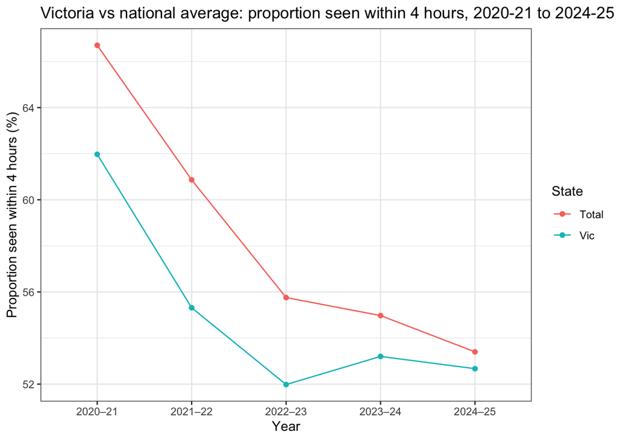

### Which hospitals are struggling the most?

Victoria performs below the national average. The next question is where inside Victoria the shortfall is coming from. The chart below breaks down compliance rates by hospital type and triage category for 2024-25.

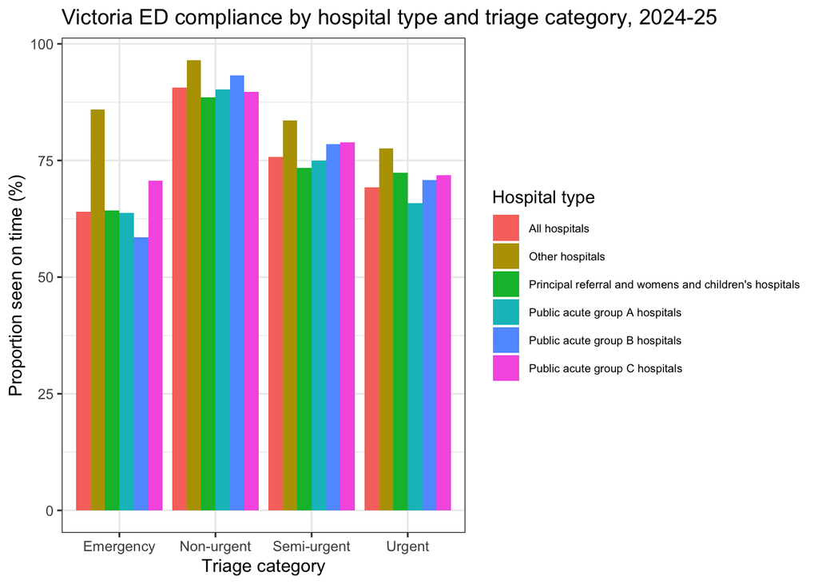

### Does remoteness explain the gap?

Hospital type explains some of the variation. But hospital type and geographic remoteness are closely linked. The chart below looks at whether remoteness alone can explain the gap in compliance rates across Victoria.

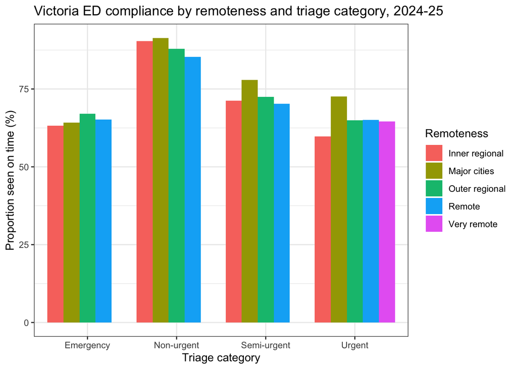

Major cities show the highest compliance rate for Semi-urgent presentations. For Urgent presentations, Inner regional areas show the lowest compliance at around 60%. The differences between remoteness areas are relatively small across most triage categories. Very remote areas have limited data available for Victoria, so a full comparison is not possible.

### Where does this leave patients on the map?

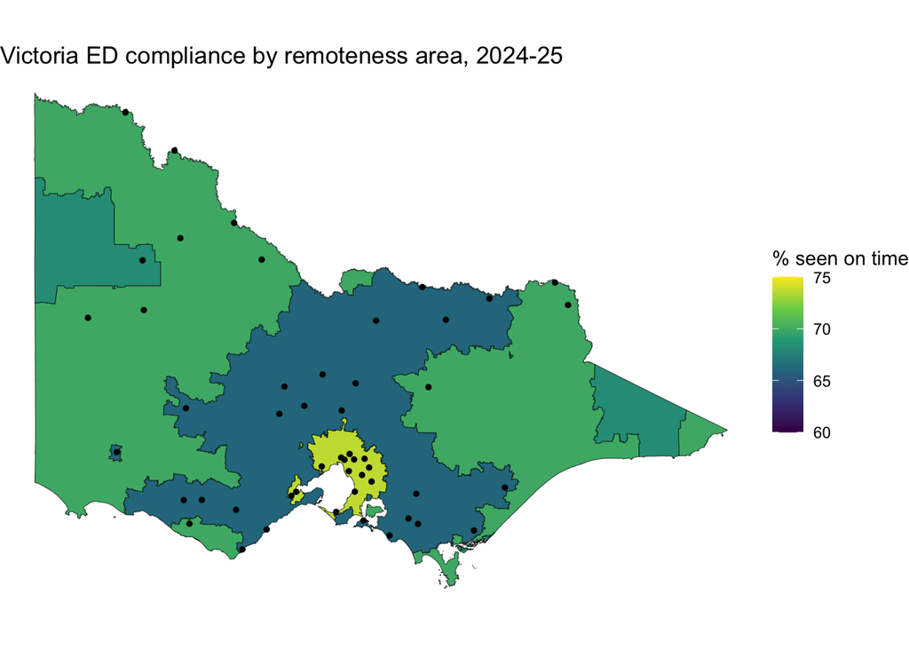

The map shows that Major cities, centred around Melbourne, have the highest compliance rate. ED locations are concentrated in and around Melbourne. Regional and remote areas have lower compliance rates and fewer ED services. Patients in these areas face both longer travel distances and lower on-time performance when they arrive.

### Does analysing ED data raise any ethical concerns?

The data used in this analysis comes from the Australian Institute of Health and Welfare. It is publicly available under an open government licence. All figures are pre-aggregated at the state and hospital peer group level. No patient-level records are included. This means there are no direct privacy concerns about individual patients.

However, there are some limitations worth noting. The data does not include information about why patients waited longer in some areas. It also does not capture the experience of individual patients. Using aggregated data to draw conclusions about specific communities should be done carefully.

I also used AI tools to help with parts of this analysis. AI was used to assist with coding and writing, but all decisions about the analysis were made by me. The raw data was never shared with any AI system.

### What else could we learn from Victoria’s emergency departments?

This analysis only uses pre-aggregated data at the state and hospital peer group level. In future, I would like to explore:

- Individual hospital-level data to identify which specific hospitals are struggling the most within each peer group.
- The reasons why patients leave without being seen, which may reveal additional pressure points in the system.
- How staffing levels and hospital capacity relate to compliance rates across different regions of Victoria.

### References

See Data Details tab.

## Behind the Scenes

#### Question 4

The most tedious part of this analysis was cleaning the AIHW Excel files. Each sheet had a different structure. Table 5.1 and Table 6.3 had the data organised by year columns, which required pivot_longer to reshape into tidy format. Table 5.3 and Table S5.2 had the data organised by state columns, which only required selecting the Victoria column. Identifying the correct structure for each sheet before writing the cleaning code took time.

The AIHW data also uses n.p. and . . to represent suppressed or unavailable values instead of leaving cells empty. These had to be identified and replaced with NA before converting the value column to numeric. This was a small but necessary step that was easy to overlook.

Preparing the choropleth map also required several repetitive steps. The remoteness area names in the ABS shapefile did not match the names in the AIHW data. Each name had to be manually matched using case_when() before the two datasets could be joined.

#### Question 5

One challenge I did not anticipate was the mismatch between column names in the raw Excel files and what R expects. Some column names contained special characters such as slashes and brackets. For example, the column State/territory could not be used directly in filter() without backticks. I resolved this by using rename() at the start of each cleaning pipeline to replace all problematic column names with clean equivalents.

A second challenge was the coordinate reference system mismatch between the two geographic files. The Geoscience Australia CSV uses WGS84 (EPSG 4326) while the ABS shapefile uses GDA94 (EPSG 4283). When I first tried to overlay the ED points on the map, the points did not align correctly. I resolved this using st_transform() to reproject the CSV points to match the shapefile’s coordinate system.

A third challenge was that Victoria has very limited data for the Very Remote category in Table S5.2. Most values were suppressed as `n.p.` or `. .`. This meant the choropleth map could not show a complete picture of all five remoteness zones for Victoria.

#### Questions 6

The main limitation of this analysis is that all AIHW data is pre-aggregated at the state and hospital peer group level. This means I cannot identify which specific hospitals within each peer group are performing poorly. Individual hospital-level data would allow a more precise analysis.

In future I would like to add staffing and capacity data to the analysis to understand whether resource levels explain the compliance gaps between hospital types and regions. I would also like to extend the time series beyond 2024-25 as new data becomes available to track whether Victoria’s recovery continues.

#### Question 7

*An additional 2 marks will be awarded for the code you used to produce your analysis and report. These marks include reproducibility, compiling of your .html, production of any figures and tables etc.*

This question doesn’t require an answer.

## AI acknowledgment

I use AI to assist me in organising my thoughts and troubleshooting, rather than directly writing the code or analysis. In this assignment, I used AI to:

- When my cleaning pipeline produced errors or warnings, such as the recycling warning from using `Vic == c("n.p.", ". .")` instead of `%in%`, and the type error requiring `NA_character_` rather than NA inside `if_else()`, the AI explained the underlying cause of each error and the correction logic. I then rewrote and tested the code myself.
- Help me better understand the purpose and usage of functions such as `pivot_longer()`, `case_when()`, `st_as_sf()` and `st_transform()`, particularly why the AIHW sheets with years as columns needed reshaping while sheets with states as columns did not, and why the ED points must be reprojected to match the shapefile’s coordinate system before mapping.
- Help me clarify what the raw data actually represented. For example, the difference between `n.p.` and `. .` in the AIHW tables and why they must become NA rather than zero, what the hospital peer group classification means, and what analysis is not possible because the data is pre-aggregated at state level rather than patient level.
- Discuss and refine my presentation choices iteratively. For instance, whether the Very Remote areas with suppressed data should be removed from the choropleth map or shown in grey, and whether to lead the blog post with the proportion seen on time or the median waiting time.

Throughout this process, the raw data files were never shared with AI; only column names, error messages and small code snippets were discussed. Although AI provided explanations and examples, all code was rewritten and verified by me, and all decisions were made through my own judgement.

Here is the link(s) to all prompts used: (https://chatgpt.com/share/6a2a6913-eb9c-83ec-b00a-97990b6f7bdf)

## GitHub repository

My iterative process can be seen in my GitHub repository: (https://github.com/ZiYYYou/ETC5512-assignment4.git)

The key commits that show my iterations are:

**Commit “Finish Task1” (dd0b4d8):** I added the data descriptions, download steps and the first version of my cleaning code. At this stage the cleaning still had problems I had not noticed: I used == instead of %in% when replacing the n.p. values, which gave a recycling warning, and the ED points were not reprojected to match the shapefile.

**Commit “Fix some issues in task1” (f5cda1f):** I fixed the n.p. cleaning bug after understanding the difference between == and %in%, added st_transform() so the ED points align with the map boundaries, and removed a duplicated sentence in Question 1. I learnt that code which runs without an error can still produce wrong results.

**Commit “Finish Task2” (ce41e1c):** I added the full blog post draft with the charts and the choropleth map. Some headings left over from the example template were still in the text, and my charts only had default axis labels.

**Commit “Add labs and fix some problems for Task 2” (330debd):** I cleaned out the template leftovers, fixed a broken paragraph, and added proper titles and axis labels to all charts with labs(). I learnt that a chart is much easier to read when the labels explain the units.